# Data Visualisation using RShiny: Day 1

Building an interactive plot in RShiny

1.4 App Guide

### Contents

Click to view a specific section of the document.

- Pre-built apps
- Important Notes
- Inputs (Widgets)
- Outputs
- More Information

### Pre-built apps

Most of the activities in this section will use a pre-built app from the Apps folder, which are all set up in a similar way:

*server.R scripts*

- The server script contains all reactive processing code used for the app
- The script starts by loading in any required package libraries, data and creating a colour palette to use
- Some scripts may also do some data processing
- The server section is opened with `shinyServer(function(input, output) {`

*ui.R scripts*

- The ui scripts contains all code that produces the screen that the app user will see
- The script starts by loading in package libraries, data and often some data processing
- The ui section is opened with `shinyUI(fluidPage(`.
- The ui uses special functions to format the text, such as `br()` which gives a line break or `h4()` which sets the font size
- There will then be some code to setup the layout with a side panel and a main panel: we use the side panel to show the widgets, and the main panel for the outputs

### Important Notes

- Each app must be contained in its own folder, because the scripts are named **server.R** and **ui.R** - which are not unique!
- Any data you use in an app must be located in the same folder as the server.R and ui.R scripts that use it. We store our data in a sub-folder called “data” to keep the app folder organised.

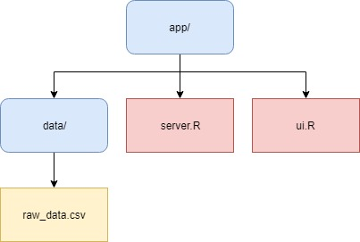

### Inputs (Widgets)

input is used in the **ui** to sets the options for the user to interact with.

| Name | Produces |
| --- | --- |
| `actionButton()` | a button click input |
| `checkboxInput()` | a single checkbox |
| `checkboxGroupInput()` | a set of checkboxes where multiple can be selected |
| `dateInput()` | a calendar for date selection |
| `dateRangeInput()` | a pair of calendars for start and end date selection |
| `numericInput()` | a free-text for numbers |
| `radioButtons()` | a set of buttons where only 1 can be selected |
| `selectInput()` | a dropdown menu |
| `sliderInput()` | a slider bar |
| `textInput()` | a free-text for letters/words |

### Outputs

render is used in the **server** to generate the output, and saved to an object as `output$___`. output is used in the **ui** to display the output to the user.

| render | output | Produces |
| --- | --- | --- |
| `renderImage()` | `imageOutput()` | an image |
| `renderPlot()` | `plotOutput()` | a plot/map |
| `renderPrint()` | `verbatimTextOutput()` | any printed output formatted as code |
| `renderTable()` | `tableOutput()` | a table |
| `DT::renderDataTable()` | `dataTableOutput()` | an interactable table |
| `renderText()` | `textOutput()` | any character string formatted to match app |
| `rendeerUI()` | `uiOutput()` or `htmlOutput()` | any character string formatted with raw HTML code |

### More Information

For more information on shiny, there is a *cheat-sheet* available [here](https://shiny.rstudio.com/images/shiny-cheatsheet.pdf)